# DNA/RNA Project

```r
cat("DIS samples:", dis, "\n")
```

```
## DIS samples: GSM5319603_3999356129_R02C02 GSM5319604_3999547012_R02C01 GSM5319609_3999547016_R02C01 GSM5319613_3999547017_R02C01
```

Suset the MSet object by groups

```r
ctrlSet <- MSet.raw[, colnames(MSet.raw) %in% ctrl]
disSet <- MSet.raw[, colnames(MSet.raw) %in% dis]
```

Calculate Beta and M values

```r
ctrlBeta <- getBeta(ctrlSet)
ctrlM <- getM(ctrlSet)
disBeta <- getBeta(disSet)
disM <- getM(disSet)
```

Calculate mean values per probe across samples

```r
mean_ctrlBeta <- apply(ctrlBeta, 1, mean, na.rm = TRUE)
mean_disBeta <- apply(disBeta, 1, mean, na.rm = TRUE)
mean_ctrlM <- apply(ctrlM, 1, mean, na.rm = TRUE)
mean_disM <- apply(disM, 1, mean, na.rm = TRUE)
```

Calculate density estimates, checking for enough data points

```r
if (sum(!is.na(mean_ctrlBeta)) >= 2) {d_mean_ctrlBeta <- density(na.omit(mean_ctrlBeta))} else {warning("Not enough points in mean_ctrlBeta for density plot.")}

if (sum(!is.na(mean_disBeta)) >= 2) {d_mean_disBeta <- density(na.omit(mean_disBeta))} else {warning("Not enough points in mean_disBeta for density plot.")}

if (sum(!is.na(mean_ctrlM)) >= 2) {d_mean_ctrlM <- density(na.omit(mean_ctrlM))} else {warning("Not enough points in mean_ctrlM for density plot.")}

if (sum(!is.na(mean_disM)) >= 2) {d_mean_disM <- density(na.omit(mean_disM))} else {warning("Not enough points in mean_disM for density plot.")}
```

Plot density of mean Beta and M values

```r
par(mfrow = c(1, 2))
```

Density of mean Beta values

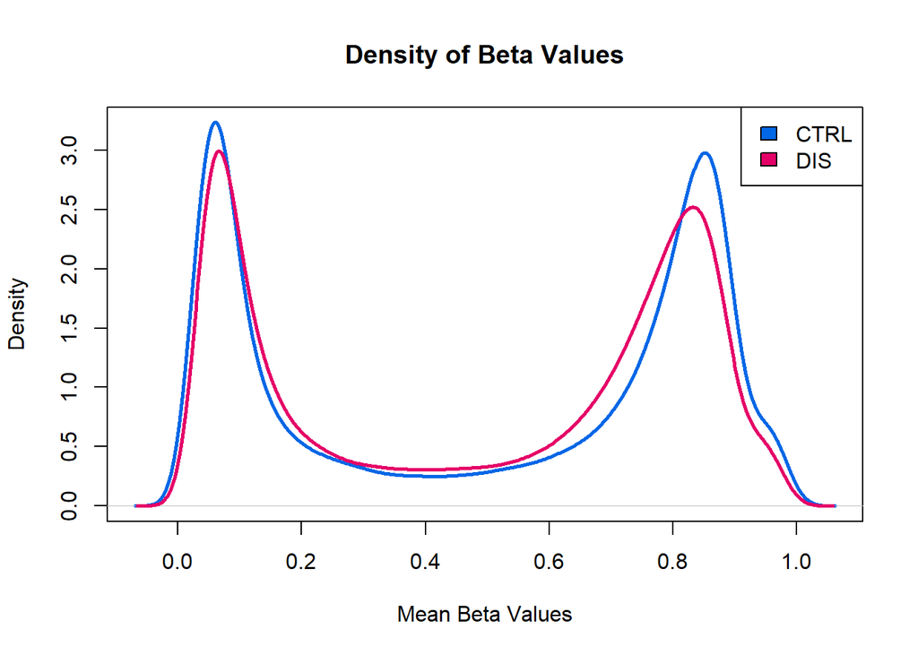

```r
plot(d_mean_ctrlBeta, main = "Density of Beta Values",col = "#0067E6",lwd = 2.5,xlab = "Mean Beta Values",ylab = "Density")
lines(d_mean_disBeta, col = "#E50068", lwd = 2.5)
legend("topright", legend = c("CTRL", "DIS"), fill = c("#0067E6", "#E50068"), cex = 1)
```

Density of mean M values

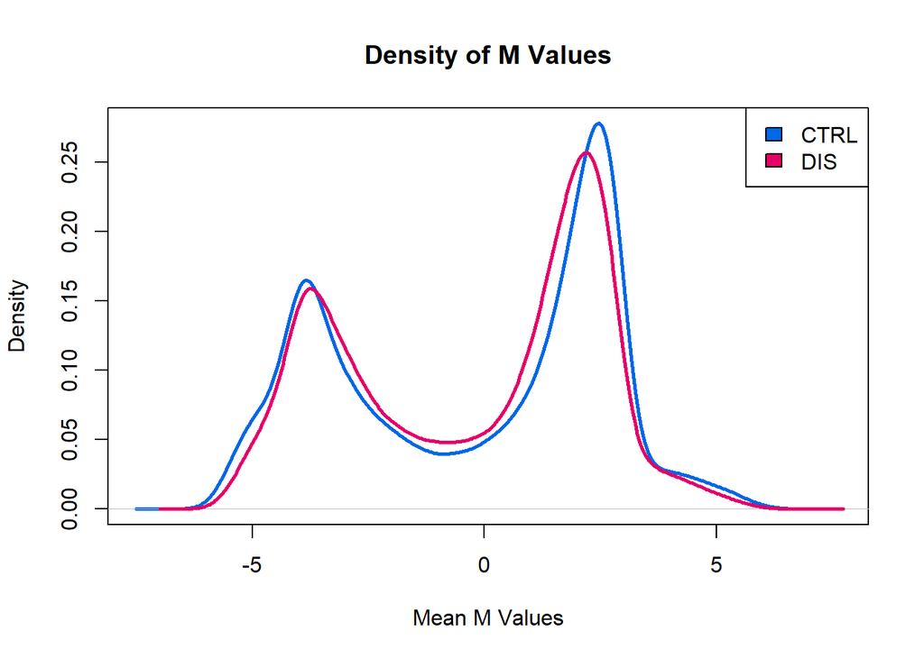

```r
plot(d_mean_ctrlM,main = "Density of M Values",col = "#0067E6",lwd = 2.5,xlab = "Mean M Values",ylab = "Density")
lines(d_mean_disM, col = "#E50068", lwd = 2.5)
legend("topright", legend = c("CTRL", "DIS"), fill = c("#0067E6", "#E50068"), cex = 1)
```

Reset plotting layout

```r
par(mfrow = c(1, 1))
```

**7. Normalize the data using the function assigned to each group and compare raw data and normalized data. Produce a plot with 6 panels in which, for both raw and normalized data, you show the density plots of beta mean values according to the chemistry of the probes, the density plot of beta standard deviation values according to the chemistry of the probes and the boxplot of beta values. Provide a short comment about the changes you observe.**  
Optional: do you think that the normalization approach that you used is appropriate considering this specific dataset? Try to color the boxplots according to the group (WT and MUT) and check whether the distribution of methylation values is different between the two groups, before and after normalization.  
Subset the manifest by probe chemistry (Type I and Type II)

```r
dfI <- Illumina450Manifest_clean[Illumina450Manifest_clean$Infinium_Design_Type == "I", ]
dfII <- Illumina450Manifest_clean[Illumina450Manifest_clean$Infinium_Design_Type == "II", ]
dfI <- droplevels(dfI)
dfII <- droplevels(dfII)
```

Subset raw beta values by chemistry

```r
beta_raw <- getBeta(MSet.raw)
beta_I_raw <- beta_raw[rownames(beta_raw) %in% dfI$IlmnID, ]
beta_II_raw <- beta_raw[rownames(beta_raw) %in% dfII$IlmnID, ]
```

Calculate mean and sd for raw Beta

```r
mean_beta_I_raw <- apply(beta_I_raw, 1, mean, na.rm = TRUE)
mean_beta_II_raw <- apply(beta_II_raw, 1, mean, na.rm = TRUE)
sd_beta_I_raw <- apply(beta_I_raw, 1, sd, na.rm = TRUE)
sd_beta_II_raw <- apply(beta_II_raw, 1, sd, na.rm = TRUE)
```

Density plots for raw Beta values

```r
density_mean_beta_I_raw <- density(na.omit(mean_beta_I_raw))
density_mean_beta_II_raw <- density(na.omit(mean_beta_II_raw))
density_sd_beta_I_raw <- density(na.omit(sd_beta_I_raw))
density_sd_beta_II_raw <- density(na.omit(sd_beta_II_raw))
```

Normalize using preprocessFunnorm

```r
MSet.norm <- preprocessFunnorm(RGset)
beta_norm <- getBeta(MSet.norm)
```

Subset normalized Beta by chemistry

```r
beta_I_norm <- beta_norm[rownames(beta_norm) %in% dfI$IlmnID, ]
beta_II_norm <- beta_norm[rownames(beta_norm) %in% dfII$IlmnID, ]
```

Calculate mean and sd for normalized Beta

```r
mean_beta_I_norm <- apply(beta_I_norm, 1, mean, na.rm = TRUE)
mean_beta_II_norm <- apply(beta_II_norm, 1, mean, na.rm = TRUE)
sd_beta_I_norm <- apply(beta_I_norm, 1, sd, na.rm = TRUE)
sd_beta_II_norm <- apply(beta_II_norm, 1, sd, na.rm = TRUE)
```

Density plots for normalized Beta values

```r
density_mean_beta_I_norm <- density(na.omit(mean_beta_I_norm))
density_mean_beta_II_norm <- density(na.omit(mean_beta_II_norm))
density_sd_beta_I_norm <- density(na.omit(sd_beta_I_norm))
density_sd_beta_II_norm <- density(na.omit(sd_beta_II_norm))
```

Plotting: 2 rows x 3 columns

```r
par(mfrow = c(2, 3))
```

Raw mean Beta densities

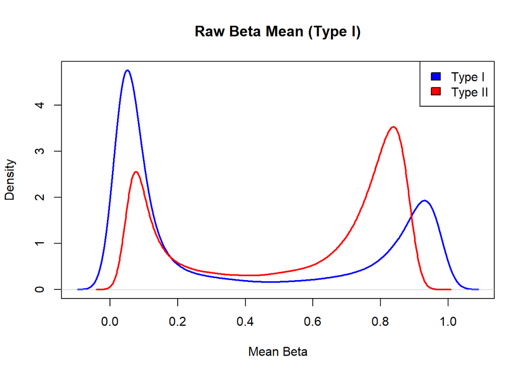

```r
plot(density_mean_beta_I_raw, main = "Raw Beta Mean (Type I)", col = "blue", lwd = 2, xlab = "Mean Beta")
lines(density_mean_beta_II_raw, col = "red", lwd = 2)
legend("topright", legend = c("Type I", "Type II"), fill = c("blue", "red"))
```

Raw sd Beta densities

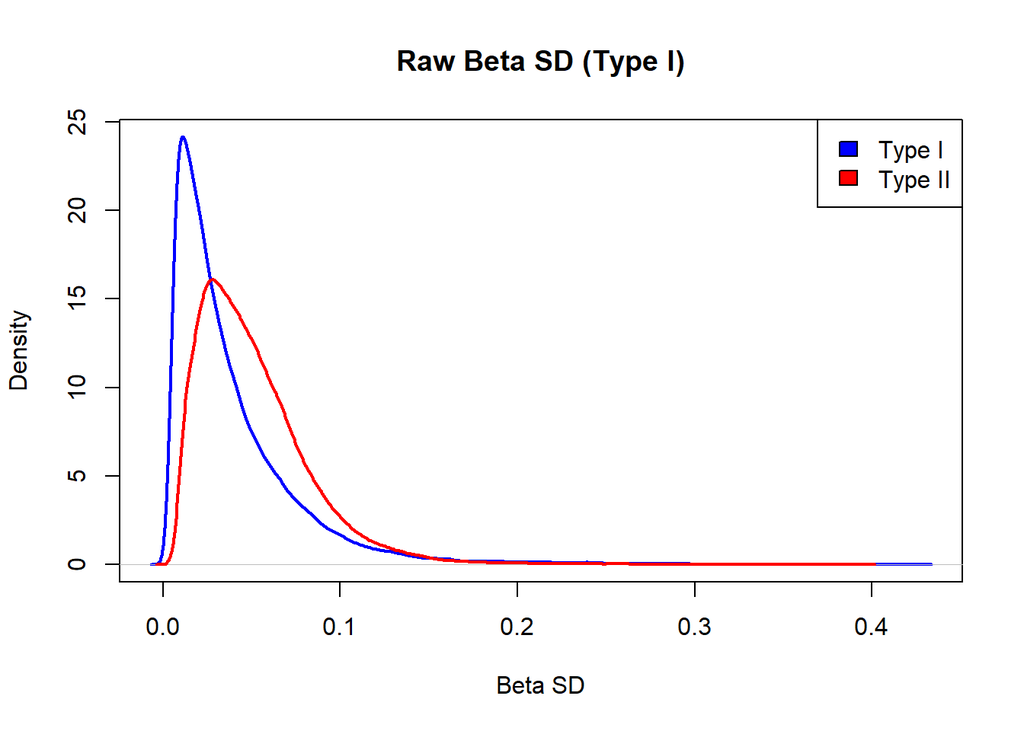

```r
plot(density_sd_beta_I_raw, main = "Raw Beta SD (Type I)", col = "blue", lwd = 2, xlab = "Beta SD")
lines(density_sd_beta_II_raw, col = "red", lwd = 2)
legend("topright", legend = c("Type I", "Type II"), fill = c("blue", "red"))
```

Raw Beta boxplot

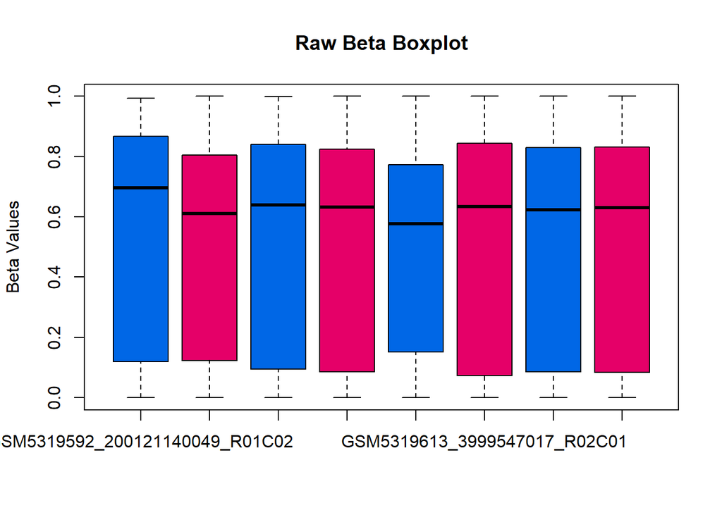

```r
boxplot(beta_raw, outline = FALSE,
        col = rep(c("#0067E6", "#E50068"), length.out = ncol(beta_raw)),
        main = "Raw Beta Boxplot", ylab = "Beta Values")
```

Normalized mean Beta densities

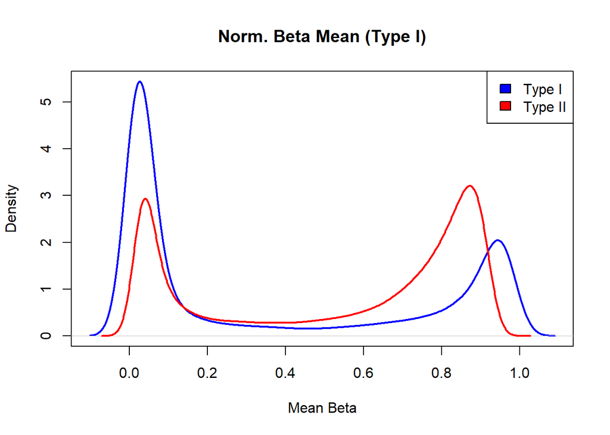

```r
plot(density_mean_beta_I_norm, main = "Norm. Beta Mean (Type I)", col = "blue", lwd = 2, xlab = "Mean Beta")
lines(density_mean_beta_II_norm, col = "red", lwd = 2)
legend("topright", legend = c("Type I", "Type II"), fill = c("blue", "red"))
```

Normalized sd Beta densities

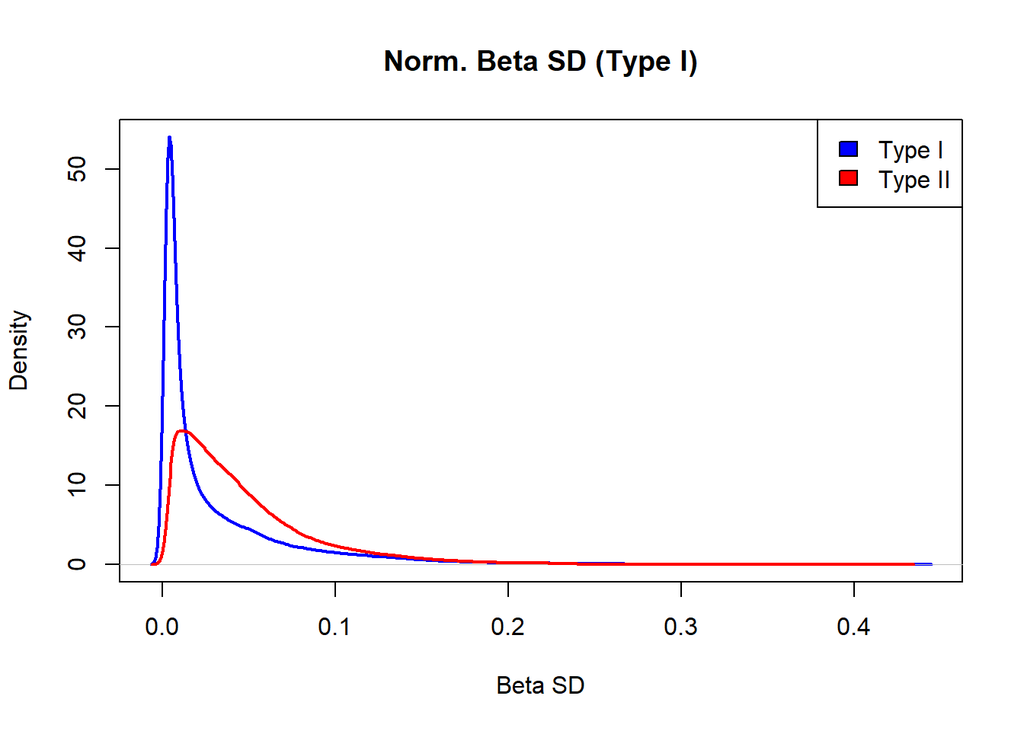

```r
plot(density_sd_beta_I_norm, main = "Norm. Beta SD (Type I)", col = "blue", lwd = 2, xlab = "Beta SD")
lines(density_sd_beta_II_norm, col = "red", lwd = 2)
legend("topright", legend = c("Type I", "Type II"), fill = c("blue", "red"))
```

Normalized Beta boxplot

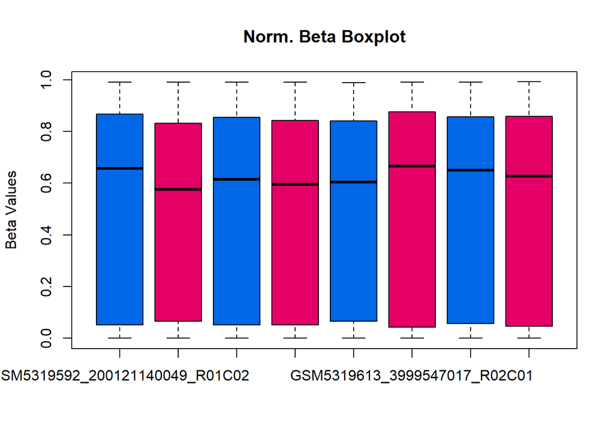

```r
boxplot(beta_norm, outline = FALSE,col = rep(c("#0067E6", "#E50068"), length.out = ncol(beta_norm)),main = "Norm. Beta Boxplot", ylab = "Beta Values")
```

Reset plotting layout

```r
par(mfrow = c(1, 1))
```

**8. Perform a PCA on the matrix of normalized beta values generated in step 7, after normalization.**  
Comment the plot (Do you see any outlier?  
Do the samples divide according to the group?  
Do they divide according to the sex of the samples?  
Do they divide according to the batch, that is the column Sentrix_ID?).

Assuming beta_norm is your matrix of normalized beta values

```r
pca_results <- prcomp(t(beta_norm), scale = TRUE)
library(factoextra)
```

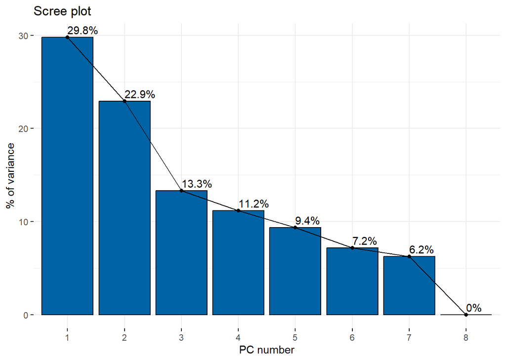

```r
fviz_eig(pca_results, addlabels = TRUE, xlab = 'PC number', ylab = '% of variance', barfill = "#0063A6", barcolor = "black")
```

PCA plot by Group

```r
targets$Group <- as.factor(targets$Group)
palette(c("#E50068", "#0067E6"))
xlim <- range(pca_results$x[, 1])
ylim <- range(pca_results$x[, 2])
```

Increase right margin, reduce top/bottom margins

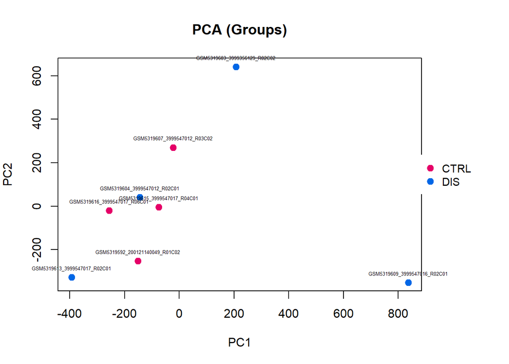

```r
par(mar = c(5, 4, 4, 6), xpd = TRUE)
plot(pca_results$x[, 1], pca_results$x[, 2],
     cex = 1.2, pch = 19, col = targets$Group,
     xlab = "PC1", ylab = "PC2",
     xlim = xlim, ylim = ylim,
     main = "PCA (Groups)")
text(pca_results$x[, 1], pca_results$x[, 2],
     labels = rownames(pca_results$x), cex = 0.4, pos = 3)
legend("right", inset = c(-0.15, 0),
       legend = levels(targets$Group),
       col = c(1, 2), pch = 19,
       cex = 0.9, pt.cex = 1.2, x.intersp = 1.2,
       box.lty = 0, bg = "white")
```

PCA plot by Sex

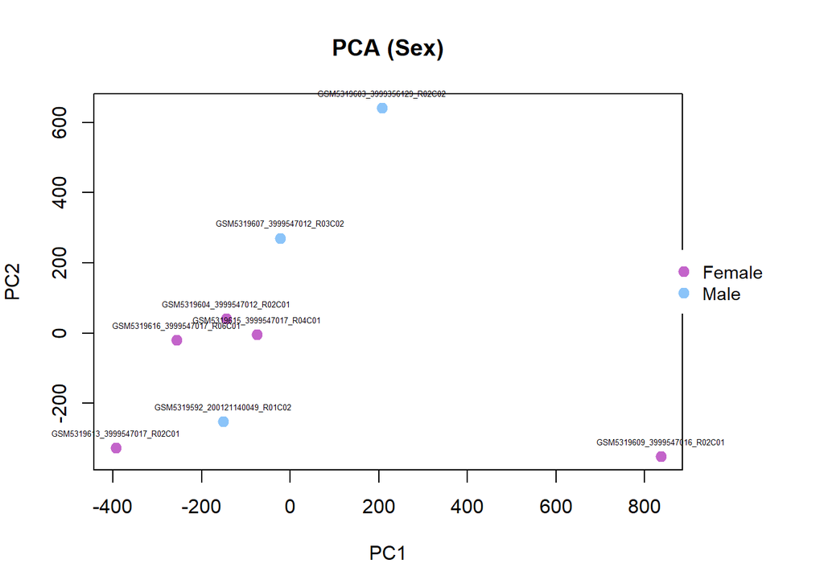

```r
targets$Sex <- as.factor(targets$Sex)
palette(c("#C364CA", "#8BC4F9"))
par(mar = c(5, 4, 4, 6), xpd = TRUE)
plot(pca_results$x[, 1], pca_results$x[, 2],
     cex = 1.2, pch = 19, col = targets$Sex,
     xlab = "PC1", ylab = "PC2",
     xlim = xlim, ylim = ylim,
     main = "PCA (Sex)")
text(pca_results$x[, 1], pca_results$x[, 2],
     labels = rownames(pca_results$x), cex = 0.4, pos = 3)
legend("right", inset = c(-0.15, 0),
       legend = levels(targets$Sex),
       col = 1:nlevels(targets$Sex), pch = 19,
       cex = 0.9, pt.cex = 1.2, x.intersp = 1.2,
       box.lty = 0, bg = "white")
```

PCA plot by Slide (Batch)

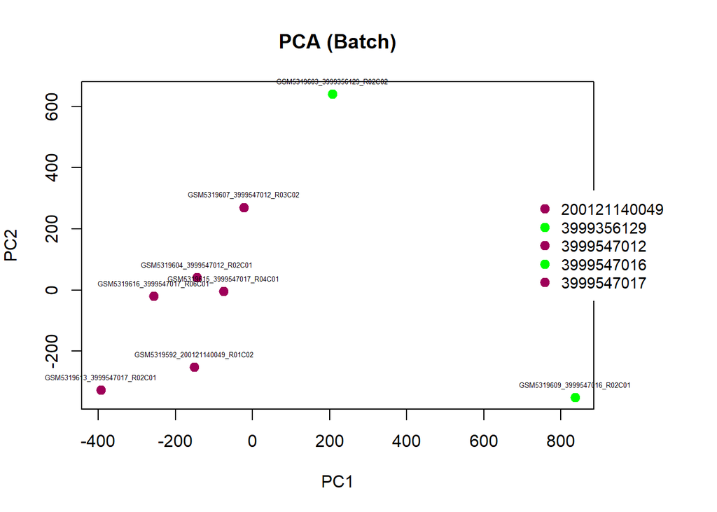

```r
targets$Slide <- as.factor(targets$Slide)
palette(c("#9e0059", "green"))
par(mar = c(5, 4, 4, 6), xpd = TRUE)
plot(pca_results$x[, 1], pca_results$x[, 2],
     cex = 1.2, pch = 19, col = targets$Slide,
     xlab = "PC1", ylab = "PC2",
     xlim = xlim, ylim = ylim,
     main = "PCA (Batch)")
text(pca_results$x[, 1], pca_results$x[, 2],
     labels = rownames(pca_results$x), cex = 0.4, pos = 3)
legend("right", inset = c(-0.15, 0),
       legend = levels(targets$Slide),
       col = c(1, 2), pch = 19,
       cex = 0.9, pt.cex = 1.2, x.intersp = 1.2,
       box.lty = 0, bg = "white")
```

**9. Using the matrix of normalized beta values generated in step 7, identify differentially methylated probes between group WT and group MUT using the function assigned to each group.**

Define the t-test function: compares beta values between groups

```r
My_t_test <- function(x) {
  t_test <- t.test(x ~ targets$Group)
  return(t_test$p.value)
}
```

Apply the t-test function to each probe (row)

```r
p_values <- apply(beta_norm, 1, My_t_test)
```

Create a data frame combining beta values with the raw p-values

```r
final_ttest <- data.frame(beta_norm, p_values_ttest = p_values)
```

Sort the probes by p-value in ascending order

```r
final_ttest <- final_ttest[order(final_ttest$p_values_ttest), ]
```

Filter significant probes with p-value <= 0.05

```r
final_ttest_th <- final_ttest[final_ttest$p_values_ttest <= 0.05, ]
```

Plot histogram of p-value distribution

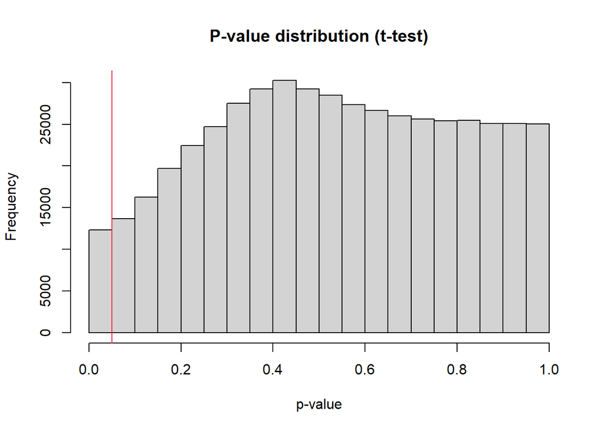

```r
hist(final_ttest$p_values_ttest, main = "P-value distribution (t-test)",
     xlab = 'p-value')
abline(v = 0.05, col = "#ef233c")
```

Check the number of differentially methylated probes before correction

```r
dim(final_ttest_th)
```

```
## [1] 12351     9
```

**10. Apply multiple test correction and set a significant threshold of 0.05. How many probes do you identify as differentially methylated considering nominal pValues? How many after Bonferroni correction? How many after BH correction?**

Apply multiple testing corrections

```r
corr_pval_BH <- p.adjust(final_ttest$p_values_ttest, method = "BH")  # Benjamini-Hochberg
corr_pval_bonferroni <- p.adjust(final_ttest$p_values_ttest, method = "bonferroni")
```

Combine the corrected p-values into the final data frame

```r
final_ttest_corr <- data.frame(final_ttest, corr_pval_BH, corr_pval_bonferroni)
```

Count the number of differentially methylated probes before and after correction

```r
before_correction <- nrow(final_ttest_corr[final_ttest_corr$p_values_ttest <= 0.05, ])
after_Bonferroni <- nrow(final_ttest_corr[final_ttest_corr$corr_pval_bonferroni <= 0.05, ])
after_BH <- nrow(final_ttest_corr[final_ttest_corr$corr_pval_BH <= 0.05, ])
```

Create a summary data frame with the results

```r
diff_meth_df <- data.frame(before_correction, after_Bonferroni, after_BH)
rownames(diff_meth_df) <- c("# differentially methylated probes")
```

Print the summary data frame

```r
diff_meth_df
```

```
##                                    before_correction after_Bonferroni after_BH
## # differentially methylated probes             12351                0        0
```

Set plotting area to a single plot

```r
par(mfrow = c(1,1))
```

Plot boxplots of raw and adjusted p-values

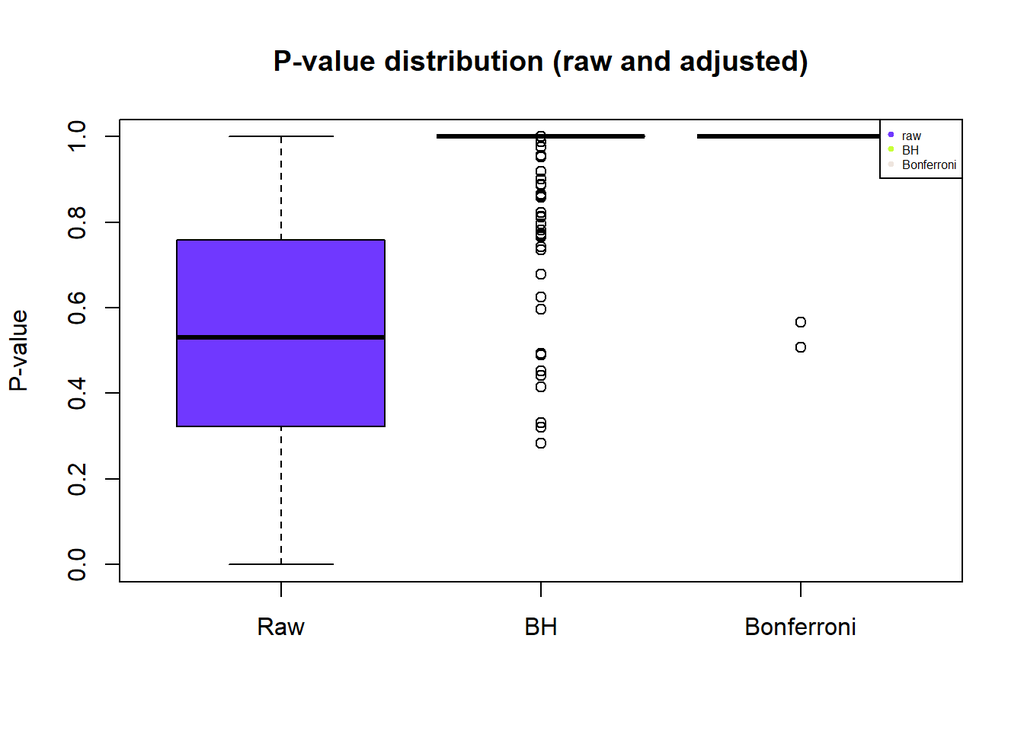

```r
boxplot(final_ttest_corr[,9:11],
        col = c("#7038FF", "#C7FF38", "seashell2"),
        names = c("Raw", "BH", "Bonferroni"),
        main = 'P-value distribution (raw and adjusted)',
        ylab = "P-value")

legend("topright",
       legend = c("raw", "BH", "Bonferroni"),
       col = c("#7038FF", "#C7FF38", "seashell2"),
       pch = 19, cex = 0.5, xpd = TRUE)
```

**11. Produce a volcano plot and a Manhattan plot of the results of differential methylation analysis**

Extract beta values (columns 1 to 8)

```r
beta <- final_ttest_corr[, 1:8]
```

Calculate mean beta-values for each group

```r
beta_groupCTRL <- beta[, targets$Group == "CTRL"]
mean_beta_groupCTRL <- apply(beta_groupCTRL, 1, mean)
beta_groupDIS <- beta[, targets$Group == "DIS"]
mean_beta_groupDIS <- apply(beta_groupDIS, 1, mean)
```

Calculate delta (DIS - CTRL)

```r
delta_average <- mean_beta_groupDIS - mean_beta_groupCTRL
```

Identify probes significant after BH correction

```r
BH_sig <- final_ttest_corr$corr_pval_BH < 0.01
```

Create a data frame for the volcano plot

```r
toVolcPlot <- data.frame(
  delta_average,
  minus_log10_p_val = -log10(final_ttest_corr$p_values_ttest),
  BH_sig
)
```

Plot the volcano plot

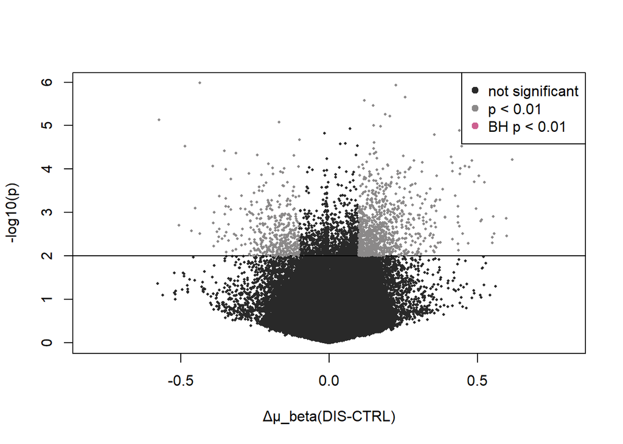

```r
plot(toVolcPlot[,1], toVolcPlot[,2],
     pch=16, cex=0.4, col='grey16',
     xlab='Δμ_beta(DIS-CTRL)', ylab='-log10(p)',
     xlim=c(-0.8,0.8))
abline(h = -log10(0.01))
nominal_sig <- toVolcPlot[
  abs(toVolcPlot[,1]) > 0.1 &
    toVolcPlot[,2] > -log10(0.01), ]
points(nominal_sig[,1], nominal_sig[,2], pch=16, cex=0.4, col="snow4")

BH_sig_points <- toVolcPlot[
  abs(toVolcPlot[,1]) > 0.1 &
    toVolcPlot$BH_sig, ]
points(BH_sig_points[,1], BH_sig_points[,2], pch=19, cex=0.6, col="hotpink3")
legend("topright",
       legend=c("not significant", "p < 0.01", "BH p < 0.01"),
       col=c("grey16", "snow4", "hotpink3"), pch = 19)
```

Manhattan Plot

Step 1: Add probe IDs as a column

```r
final_ttest_corr_anno <- data.frame(rownames(final_ttest_corr), final_ttest_corr)
colnames(final_ttest_corr_anno)[1] <- "IlmnID"
```

Step 2: Merge with Illumina manifest file (must contain IlmnID, CHR, MAPINFO)

```r
final_ttest_corr_anno <- merge(final_ttest_corr_anno, Illumina450Manifest_clean, by = "IlmnID")
```

Step 3: Prepare the data frame for qqman

```r
input_Manhattan <- data.frame(
  ID = final_ttest_corr_anno$IlmnID,
  CHR = final_ttest_corr_anno$CHR,
  MAPINFO = final_ttest_corr_anno$MAPINFO,
  PVAL = final_ttest_corr_anno$p_values_ttest
)
```

Step 4: Convert chromosomes X and Y to numeric (23 and 24)

```r
levels(input_Manhattan$CHR)[levels(input_Manhattan$CHR) == "X"] <- "23"
levels(input_Manhattan$CHR)[levels(input_Manhattan$CHR) == "Y"] <- "24"
input_Manhattan$CHR <- as.numeric(as.character(input_Manhattan$CHR))
```

Step 5: Load the qqman library and define a color palette

```r
library(qqman)
color_palette <- c(
  "#1F77B4", "#FF7F0E", "#2CA02C", "#D62728", "#9467BD", "#8C564B", "#E377C2",
  "#7F7F7F", "#BCBD22", "#17BECF", "#AEC7E8", "#FFBB78", "#98DF8A", "#FF9896",
  "#C5B0D5", "#C49C94", "#F7B6D2", "#C7C7C7", "#DBDB8D", "#9EDAE5",
  "#1F77B4", "#FF7F0E", "#2CA02C", "#D62728"
)
```

Step 6: Plot the Manhattan plot

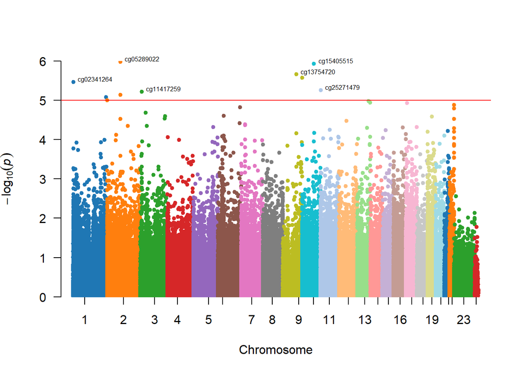

```r
manhattan(
  input_Manhattan,
  snp = "ID",
  chr = "CHR",
  bp = "MAPINFO",
  p = "PVAL",
  annotatePval = 0.00001,
  col = color_palette,
  suggestiveline = FALSE,
  genomewideline = -log10(0.00001)
)
```

**12. Produce an heatmap of the top 100 significant, differentially methylated probes.**

Load required library

```r
if (!require("gplots")) install.packages("gplots")
library(gplots)
```

Prepare the input matrix for the heatmap

```r
input_heatmap <- as.matrix(final_ttest[1:100, 1:8])
```

Assign colors to groups

```r
group_color <- c()
for (name in colnames(beta)) {
  if (targets$Group[which(colnames(beta) == name)] == "CTRL") {
    group_color <- c(group_color, "#CBCBCB")  # Light gray
  } else {
    group_color <- c(group_color, "#393939")  # Dark gray
  }
}
```

Save Average linkage heatmap

```r
png("Average_linkage_heatmap.png", width = 1200, height = 1000)
heatmap.2(input_heatmap,
          col = terrain.colors(100),
          Rowv = TRUE,
          Colv = TRUE,
          hclustfun = function(x) hclust(x, method = 'average'),
          dendrogram = "both",
          key = TRUE,
          ColSideColors = group_color,
          density.info = "none",
          trace = "none",
          scale = "none",
          symm = FALSE,
          main = "Average linkage",
          key.xlab = 'beta-val',
          key.title = NA,
          keysize = 1,
          labRow = NA)
legend("topright",
       legend = levels(targets$Group),
       col = c('#CBCBCB', '#393939'),
       pch = 19,
       cex = 0.7)
dev.off()
```

Save Complete linkage heatmap

```r
png("Complete_linkage_heatmap.png", width = 1200, height = 1000)
heatmap.2(input_heatmap,
          col = terrain.colors(100),
          Rowv = TRUE,
          Colv = TRUE,
          dendrogram = "both",
          key = TRUE,
          ColSideColors = group_color,
          density.info = "none",
          trace = "none",
          scale = "none",
          symm = FALSE,
          main = "Complete linkage",
          key.xlab = 'beta-val',
          key.title = NA,
          keysize = 1,
          labRow = NA)
legend("topright",
       legend = levels(targets$Group),
       col = c('#CBCBCB', '#393939'),
       pch = 19,
       cex = 0.7)
dev.off()
```

Save Single linkage heatmap

```r
png("Single_linkage_heatmap.png", width = 1200, height = 1000)
heatmap.2(input_heatmap,
          col = terrain.colors(100),
          Rowv = TRUE,
          Colv = TRUE,
          hclustfun = function(x) hclust(x, method = 'single'),
          dendrogram = "both",
          key = TRUE,
          ColSideColors = group_color,
          density.info = "none",
          trace = "none",
          scale = "none",
          symm = FALSE,
          main = "Single linkage",
          key.xlab = 'beta-val',
          key.title = NA,
          keysize = 1,
          labRow = NA)
legend("topright",
       legend = levels(targets$Group),
       col = c('#CBCBCB', '#393939'),
       pch = 19,
       cex = 0.7)
dev.off()
```